# Seminar and Clinic: Body Movement Reprocessing

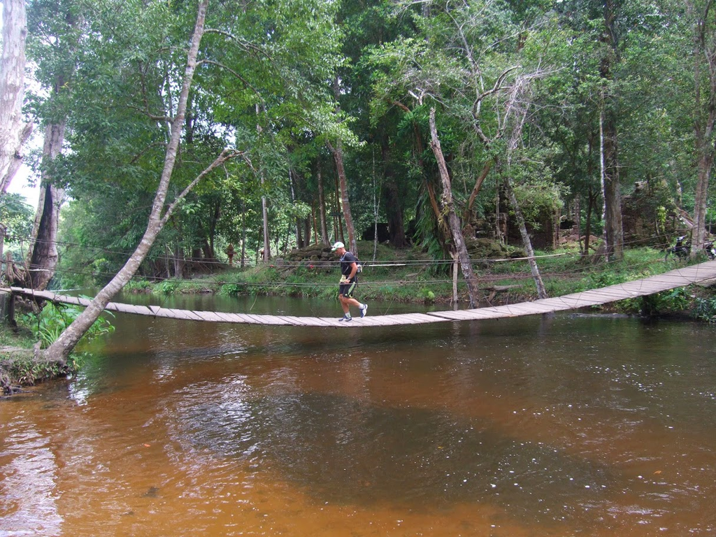

Introduction

[figure not shown]

By focusing your attention on your breathing, muscles and body posture during exercise you will experience the thrill of flow in consciousness, which relaxes your mind and body during exercise.

Body Movement Reprocessing Therapy can be seen as partially a specific form of meditation from the Buddhist philosophy of life.

By consciously focusing your attention during physical exercise on inner body sensations your consciousness experience a wholesome state of health and wellbeing.

Edward F. Hillenaar, MSc. is an exercise scientist, (sport) psychologist and CEO of Total Health, a practice for therapy/ coaching and guidance to wholesome physical and psychological health.

[figure not shown]

He also is a serious active endurance athlete and has participated several times in ultra-marathons in Asia (‘The Ancient Khmer Path’ in Cambodia in 2012 and the ‘Ultra India Race’ in 2014).

The beneficial influence of Mindful Movement, or Mindful Running on the psychological and physical health is well known by him on both academic and personal level.

At an academic level he is engaged in a PhD-study (‘Mindful Running and Psychological Distress’) at the Free University of Amsterdam to scientifically test his method of Body Movement Reprocessing Therapy on Psychological Health.

Speaker

[figure not shown]

Edward F. Hillenaar, MSc  
Date  
Saturday, 28 januari, 2023  
Van 13.00 – 17.00 uur  
(12.30 uur present)  
Location  
Centrum De Roos  
Pieter Cornelisz Hooftstraat 183  
1071 BW Amsterdam  
Fee  
25 EURO (max. 25)  
#mindfulmovement  
#psychologicalhealth  
#mindfulness  
#meditation  
#psychologicalstress  
#buddhism  
#mindfulrunning  
#bodymovement  
#reprocessingtherapy  
Organization:

[figure not shown]

Site [developed](https://github.com/EdwardHill15/BMR) by Edward Hillenaar  
Last updated on 2022-11-18